# Final Exam - 175 Points

## Case Study: Identifying and Exploring the Properties of Malignant Breast Tumors

In this analysis, we would like to build a classifier model that predicts whether a breast tumor is malignant or benign, based on it's tissue sample properties for *new* datasets. In addition, we would like to learn more about what tissue sample attribute properties (and attribute relationships) characterize malignant vs. benign breast tumor tissue samples.

The data in the **breast_tumor_scaled.csv** file contains a **random sample** of benign and malignant breast tumor tissue samples from 569 patients.

### More Dataset Information

The following physical attributes are computed from a digitized image of a fine needle aspirate (FNA) of a breast mass. They describe characteristics of the cell nuclei present in the image.

*Interesting Factoid: Furthermore, each of these physical attributes have already been **scaled**, so they should all roughly have the same standard deviation and mean. Scaling variables before running a regularized regression first can help the results not be dominated just by variables that have much larger scale.*

Specifically, the data in the **breast_tumor_scaled.csv** file contains the following attributes about these breast tumor tissue samples.

- **diagnosis** - whether the tumor was malignant ('M') or benign ('B')
- **radius_mean**
- **texture_mean**
- **perimeter_mean**
- **area_mean**
- **smoothness_mean**
- **compactness_mean**
- **concavity_mean**
- **concave points_mean**
- **symmetry_mean**
- **fractal dimension_mean**

## Points

| Problem | Points |
| --- | --- |
| 1.1 | 5 |
| 2.1.1 | 3 |
| 2.1.2 | 2.5 |
| 2.2.1 | 3 |
| 2.2.2 | 2.5 |
| 2.2.3 | 2.5 |
| 2.2.4 | 2.5 |
| 3.1 | 2 |
| 3.2 | 3.5 |
| 3.3 | 2.5 |
| 3.4 | 2.5 |
| 3.5 | 2.5 |
| 3.6 | 2.5 |
| 3.7 | 2 |
| 3.8 | 2.5 |
| 4.1.1 | 2 |
| 4.1.2 | 2 |
| 4.1.3 | 2.5 |
| 4.2.1 | 2 |
| 4.2.2 | 2 |
| 4.2.3 | 2.5 |
| 4.3.1 | 2.5 |
| 4.3.2 | 2.5 |
| 4.3.3 | 2.5 |
| 4.3.4 | 2 |
| 4.3.5 | 2 |
| 4.3.6 | 2 |
| 4.3.7 | 2.5 |
| 4.4.1 | 2.5 |
| 4.4.2 | 2.5 |
| 4.4.3 | 2.5 |
| 4.4.4 | 2 |
| 4.4.5 | 2 |
| 4.4.6 | 2 |
| 4.5.1 | 2.5 |
| 4.5.2 | 2.5 |
| 4.5.3.1 | 2 |
| 4.5.3.2 | 2.5 |
| 4.5.3.3 | 2.5 |
| 4.5.3.4 | 2 |
| 4.5.4 | 2 |
| 4.6.1 | 3 |
| 4.6.2 | 3 |
| 4.7.1 | 2.5 |
| 4.7.2 | 2 |
| 4.7.3 | 3.5 |
| 4.7.4.1 | 2 |
| 4.7.4.2 | 2 |
| 4.7.5.1 | 2.5 |
| 4.7.5.2 | 2.5 |
| 5.1.1 | 2 |
| 5.1.2 | 2 |
| 5.2.1 | 2.5 |
| 5.2.2 | 2.5 |
| 5.2.3 | 2.5 |
| 5.2.4 | 2.5 |
| 5.2.5 | 2.5 |
| 5.2.6 | 2.5 |
| 5.2.7 | 2 |
| 5.3.1 | 2 |
| 5.3.2 | 2.5 |
| 5.3.3 | 2.5 |
| 5.3.4 | 2 |
| 5.3.5 | 2 |
| 5.4.1.1 | 2 |
| 5.4.1.2 | 2.5 |
| 5.4.1.3 | 2 |
| 5.4.2 | 3 |
| 5.5.1 | 2.5 |
| 5.5.2 | 2.5 |
| 5.5.3 | 2 |
| 6 | 4 |
| Total | 175 |

[output not shown]

## UIUC Academic Integrity Policy

## WRITE YOUR FULL NAME BELOW BEFORE BEGINNING

This is a an open notes takehome exam. **However, you are not allowed to discuss this exam, open someone else's exam, or share/send your exam to anyone else except for Dr. Ellison until after the 24 hour exam period is over.**

By writing your full name in the textbox below you are indicating that you have read and are aware of the academic dishonesty policies http://courses.las.illinois.edu/fall2022/stat207/syllabus.html which indicates that evidence of cheating on the exam results in an automatic F in the course.

Sabir Rahman

### Imports

```python
import pandas as pd
import numpy as np
import seaborn as sns
import matplotlib.pyplot as plt

from scipy.stats import t, norm, f

import statsmodels.api as sm
import statsmodels.formula.api as smf

from sklearn.linear_model import LogisticRegression
from sklearn.linear_model import Lasso, LinearRegression
from sklearn.model_selection import train_test_split

from sklearn.metrics import roc_curve
from sklearn.metrics import roc_auc_score

from sklearn.metrics import confusion_matrix
```

# Part 1 - Breast Tumor Analysis

## 1. Data Preprocessing and Cleaning

We will be using all of the variables in the **breast_tumor_scaled.csv** file for this analysis. **There may or may not be missing values in this file. It is your job to determine this in 1.1 below.**

### 1.1. Missing Value Cleaning

We plan to analyze all of the variables in this dataset. In order to ensure that our subsequent functions work appropriately on these variables, you should do the following.

1. Identify any values (if any) that have been encoded in the csv to represent a **missing value**.
2. Make sure that the values in each of your numerical variables are represented as numerical values (either float64 or int64 object types). If not, fix this using the methods we discussed in class.
3. Delete any rows in your dataframe that have missing values. Remember, some "missing values" in the way that they're currently encoded in the csv may not be initially detectable by Python. It is your job to figure out what these missing values are represented by and make it so Python does detect them. And then delete any rows that have these missing values.
4. Determine how many rows that you dropped.

```python
df = pd.read_csv('breast_tumor_scaled.csv')
df.head()
```

|  | diagnosis | radius_mean | texture_mean | perimeter_mean | area_mean | smoothness_mean | compactness_mean | concavity_mean | concavepoints_mean | symmetry_mean | fractal_dimension_mean |
| --- | --- | --- | --- | --- | --- | --- | --- | --- | --- | --- | --- |
| 0 | M | 1.097064 | -2.073335 | 1.269934 | 0.984375 | 1.568466 | 3.283515 | 2.652873984 | 2.532475216 | 2.217515 | 2.255747 |
| 1 | M | 1.829821 | -0.353632 | 1.685955 | 1.908708 | -0.826962 | -0.487072 | -0.023845855 | 0.548144156 | 0.001392 | -0.868652 |
| 2 | M | 1.579888 | 0.456187 | 1.566503 | 1.558884 | 0.942210 | 1.052926 | 1.363478452 | 2.037230756 | 0.939685 | -0.398008 |
| 3 | M | -0.768909 | 0.253732 | -0.592687 | -0.764464 | 3.283553 | 3.402909 | 1.91589718 | 1.451707357 | 2.867383 | 4.910919 |
| 4 | M | 1.750297 | -1.151816 | 1.776573 | 1.826229 | 0.280372 | 0.539340 | 1.371011434 | 1.428492773 | -0.009560 | -0.562450 |

```python
len(df)
```

```
569
```

```python
df.dtypes
```

```
diagnosis                  object
radius_mean               float64
texture_mean              float64
perimeter_mean            float64
area_mean                 float64
smoothness_mean           float64
compactness_mean          float64
concavity_mean             object
concavepoints_mean         object
symmetry_mean             float64
fractal_dimension_mean    float64
dtype: object
```

```python
df["concavity_mean"].unique()
```

[output not shown]

[output cut: 77 more lines]

```
       '-0.370614157', '0.989340313', '0.106725844', '0.376657723',
       '-0.088503956', '-0.421085141', '1.43378629', '-0.685995031',
       '0.69932048', '-0.08260312', '-0.175007707', '-0.574757987',
       '0.855002122', '0.656633579', '-0.509095488', '-0.627739965',
       '-0.696541207', '1.785325481', '-1.051256805', '-0.43878765',
       '-0.822342017', '-0.792837835', '-0.587438508', '-0.743496799',
       '0.153179237', '-0.640169387', '-0.45171927', '-0.587564058',
       '-0.89490975', '0.797249255', '-0.454104715', '1.502838631',
       '0.721919428', '-0.548015899', '0.046713082', '-0.269044441',
       '0.15192374', '-0.59949128', '-0.739855857', '-0.65184551',
       '-0.741488003', '-0.987816536', '-0.567727203', '-0.821463169',
       '-0.920521891', '-0.509221038', '-0.613176199', '-0.337092384',
       '-0.361700128', '-1.051784114', '0.177033682', '0.281239943',
       '-0.554670033', '2.086644787', '2.870074984', '1.947284608',
       '0.693042995', '0.046587533', '3.296944001'], dtype=object)
```

```python
df["concavepoints_mean"].unique()
```

[output not shown]

[output cut: 78 more lines]

```
       '0.481595681', '-0.416034904', '1.325316843', '0.553560892',
       '-0.703121927', '-0.08484017', '0.93582771', '-0.58111639',
       '-0.606394493', '0.846064652', '-0.140039293', '-0.14365045',
       '-0.592723682', '1.175969686', '1.170810889', '0.106035299',
       '-0.489289813', '-0.637347272', '-1.115722468', '-0.286033233',
       '-0.638636971', '-0.872330451', '-0.448793261', '-0.579052872',
       '0.444452347', '-0.540103959', '-0.116566769', '-0.705443385',
       '-0.776892716', '1.356269622', '-0.542683357', '2.14814488',
       '0.321672991', '-0.093094245', '-0.909989665', '-0.258433672',
       '-0.481035739', '-0.417066663', '-0.631672596', '-1.120081651',
       '-0.632962295', '-1.013810444', '-1.051340688', '-0.679649403',
       '-0.875167789', '-0.931140731', '-0.657466578', '-0.555580348',
       '-0.973958741', '-0.298156404', '-0.20297661', '-0.151646585',
       '1.17029501', '2.540213411', '2.320964561', '1.263669226',
       '0.105777359', '2.65886573'], dtype=object)
```

```python
df["diagnosis"].unique()
```

```
array(['M', 'B'], dtype=object)
```

```python
missing_values = ["data unavailable", "nan"]
dfc = pd.read_csv('breast_tumor_scaled.csv', na_values=missing_values)
```

```python
dfc.dropna(how='any', inplace=True)
```

```python
dfc.dtypes
```

```
diagnosis                  object
radius_mean               float64
texture_mean              float64
perimeter_mean            float64
area_mean                 float64
smoothness_mean           float64
compactness_mean          float64
concavity_mean            float64
concavepoints_mean        float64
symmetry_mean             float64
fractal_dimension_mean    float64
dtype: object
```

```python
dfc['concavepoints_mean'].unique()
```

[output not shown]

[output cut: 51 more lines]

```
       -0.0118432 , -0.54190954,  1.81798191, -0.45395206, -0.66675241,
       -0.93655747, -0.184147  ,  0.74030932, -0.96544673, -0.93784717,
        0.01524048,  0.04696708, -0.65076014,  1.10684181,  1.62968584,
        0.32244681,  0.48159568, -0.4160349 ,  1.32531684,  0.55356089,
       -0.70312193, -0.08484017,  0.93582771, -0.58111639, -0.60639449,
        0.84606465, -0.14003929, -0.14365045, -0.59272368,  1.17596969,
        1.17081089,  0.1060353 , -0.48928981, -0.63734727, -1.11572247,
       -0.28603323, -0.63863697, -0.87233045, -0.44879326, -0.57905287,
        0.44445235, -0.54010396, -0.11656677, -0.70544339, -0.77689272,
        1.35626962, -0.54268336,  2.14814488,  0.32167299, -0.09309425,
       -0.90998967, -0.25843367, -0.48103574, -0.41706666, -0.6316726 ,
       -1.12008165, -0.6329623 , -1.01381044, -1.05134069, -0.6796494 ,
       -0.87516779, -0.93114073, -0.65746658, -0.55558035, -0.97395874,
       -0.2981564 , -0.20297661, -0.15164659,  1.17029501,  2.54021341,
        2.32096456,  1.26366923,  0.10577736,  2.65886573])
```

```python
569-556
```

```
13
```

13 rows were dropped

## 2. Descriptive Analytics and Exploring the Data

Before building our classifier, let's see if we can notice any major distinctions in the physical properties of benign and malignant tumors.

### 2.1. *Physical Attributes* with Strong Distinctions between Malignant and Benign Tumors

First, we would like to determine which physical attributes have strong associations with the diagnosis variable.

#### 2.1.1. 10 Side-by-Side Boxplots Figues

To help us answer this question, create 10 side-by-side boxplots figures.

- One that visualizes the relationship between diagnosis and radius_mean
- One that visualizes the relationship between diagnosis and texture_mean
- One that visualizes the relationship between diagnosis and perimeter_mean
- One that visualizes the relationship between diagnosis and area_mean
- One that visualizes the relationship between diagnosis and smoothness_mean
- One that visualizes the relationship between diagnosis and compactness_mean
- One that visualizes the relationship between diagnosis and concavity_mean
- One that visualizes the relationship between diagnosis and concavepoints_mean
- One that visualizes the relationship between diagnosis and symmetry_mean
- One that visualizes the relationship between diagnosis and fractal_dimension_mean

*Hint: a for loop will help this work go faster*

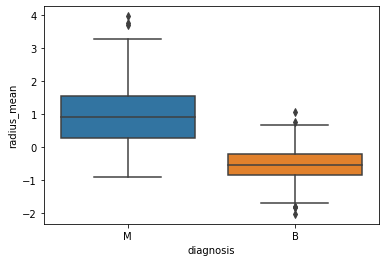

```python
sns.boxplot(data = dfc, x = "diagnosis", y = "radius_mean")
plt.show()
```

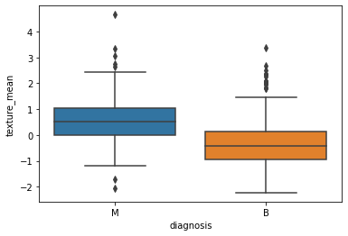

```python
sns.boxplot(data = dfc, x = "diagnosis", y = "texture_mean")
plt.show()
```

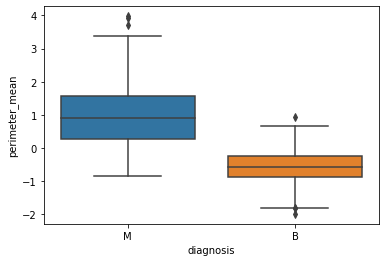

```python
sns.boxplot(data = dfc, x = "diagnosis", y = "perimeter_mean")
plt.show()
```

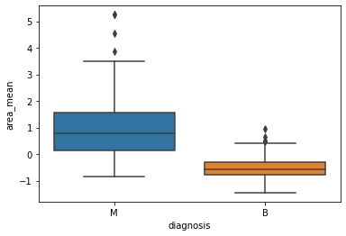

```python
sns.boxplot(data = dfc, x = "diagnosis", y = "area_mean")
plt.show()
```

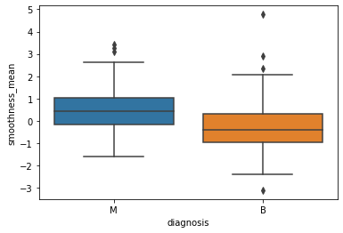

```python
sns.boxplot(data = dfc, x = "diagnosis", y = "smoothness_mean")
plt.show()
```

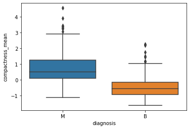

```python
sns.boxplot(data = dfc, x = "diagnosis", y = "compactness_mean")
plt.show()
```

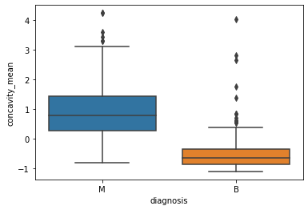

```python
sns.boxplot(data = dfc, x = "diagnosis", y = "concavity_mean")
plt.show()
```

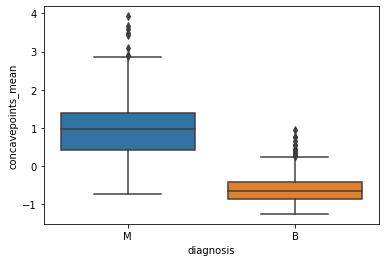

```python
sns.boxplot(data = dfc, x = "diagnosis", y = "concavepoints_mean")
plt.show()
```

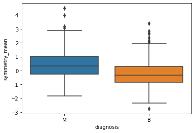

```python
sns.boxplot(data = dfc, x = "diagnosis", y = "symmetry_mean")
plt.show()
```

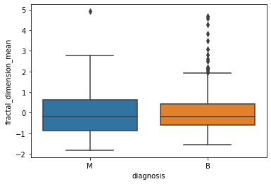

```python
sns.boxplot(data = dfc, x = "diagnosis", y = "fractal_dimension_mean")
plt.show()
```

#### 2.1.2. Strong and Weak Associations with Diagnosis

- What is a physical attribute that has a *strong* association with the diagnosis variable?
- What is a physical attribute that has the *weakest* association with the diagnosis variable?

A physical attribute that has a strong association is concavepoints_mean

A physical atribute that has the weakest association is fractal_dimension_mean